# Unexpected Data: Detection & Correction

Detecting Invalid Values

# Overview

- Unexpected and invalid values
- Methods for detecting unexpected or invalid values
- Example dataset

## Objective

- Identify methods for detecting unexpected or invalid values

## Unexpected or invalid values

Situation

Examples

Invalid values

- Out of numerical range
  - Typo
  - True outlier
- Invalid category or character string

Unexpected values

- Wrong type (char vs num)
- Incorrect or inconsistent cases (e.g. MALE vs male)
- Duplicates

Conditionally invalid

- Value appears valid alone, but is invalid because of other information
  - e.g. city = Oakland, state = AZ are not a valid combo
  - e.g. number of positive tests cannot be higher than the number of total test

Missing

- Values that should not be missing
- Values that should be missing

## Example

The data we will use tracks the testing counts by group.

**Goal:** Calculate positivity rates by day for Group 1 and Group 2 in August 2020.

Columns:

- test_date
- group
- total_tests
- pos_tests
- group_pop

```r
# load data
file_path <- "data/testing_example.xlsx"

testing <- readxl::read_excel(
  file_path,
  na="NA"
)

#confirm total_tests is now numeric
str(testing)
```

```
tibble [70 × 5] (S3: tbl_df/tbl/data.frame)
 $ test_date  : POSIXct[1:70], format: "2020-08-01" "2020-08-02" ...
 $ group      : chr [1:70] "group 1" "group 1" "group 1" "group 1" ...
 $ total_tests: num [1:70] 95 41 20 NA 48 62 57 0 0 68 ...
 $ pos_tests  : num [1:70] 8 3 1 0 0 0 0 0 1 2 ...
 $ group_pop  : num [1:70] 23012 23012 23012 23012 23012 ...
```

## Detecting invalid and unexpected values

### Handling unexpected values

**Identifying and detecting**

**Handling and/or correcting**

- Looking at the data
- Creating temporary variables
- Functions for frequency or summary
- Plots
- Excluding rows / values
- Recoding values to other values
- Recoding to missing
- Filling in missing

### Old fashioned way

- Look at the data!
- Sort and scroll
- Logical comparisons
- New temporary variables

These methods are helpful for detecting outliers and whether values are conditionally invalid.

### Utilize descriptive functions

- `unique()` - list of unique values
- `table` - frequency
  - useNA to include frequency of `NA` (“ifany” to include when relevant, “always” to include regardless)
  - can cross tab
- `summary()` - numeric statistics
- `sum(is.na())` - count number of missing

We can see two dates have a value of `NA`. Here’s three ways to find that out!

```r
#frequency base R
table(testing$test_date, useNA = "always")
```

```
2000-08-01 2020-08-01 2020-08-02 2020-08-03 2020-08-04 2020-08-05 2020-08-06
         1          2          2          2          2          2          2
2020-08-07 2020-08-08 2020-08-09 2020-08-10 2020-08-11 2020-08-12 2020-08-13
         3          2          2          2          2          2          2
2020-08-14 2020-08-15 2020-08-16 2020-08-17 2020-08-18 2020-08-19 2020-08-20
         2          2          2          2          2          2          2
2020-08-21 2020-08-22 2020-08-23 2020-08-24 2020-08-25 2020-08-26 2020-08-27
         2          2          2          2          2          2          2
2020-08-28 2020-08-29 2020-08-30 2020-08-31 2020-09-01 2020-09-25       <NA>
         2          2          3          2          2          1          2
```

```r
#frequency tidyverse
date_freq <- testing %>%
  group_by(test_date) %>%
  summarize(count=n())
```

```r
summary(as_date(testing$test_date))
```

```
        Min.      1st Qu.       Median         Mean      3rd Qu.         Max.
"2000-08-01" "2020-08-08" "2020-08-16" "2020-05-01" "2020-08-25" "2020-09-25"
        NA's
         "2"
```

```r
sum(is.na(testing$test_date))
```

```
[1] 2
```

We can also see that we have dates outside of 2020, which we’ll need to remove later.

Field

Issue

Test date

- Out of range and missing

Now let’s take a look at the groups. We’re only interested in Groups 1 and 2.

```r
unique(testing$group)
```

```
[1] "group 1"  "1"        "gp one"   "gp 1"     "group 2"  "Gp Two"   "grorup 3"
[8] NA
```

```r
table(testing$group, useNA = "ifany")
```

```
       1     gp 1   gp one   Gp Two grorup 3  group 1  group 2     <NA>
       1        1        1        1        1       29       35        1
```

Seems like we have a number of typos and potentially groups outside of 1 and 2 that we don’t need. We’ll need to standardize group names, remove group 3 and the `NA`’s before analyzing. It will also be more meaningful to have the groups named for the city (group 1 represents San Diego and group 2 represents LA).

Field

Issue

Group

- Invalid group names; missing
- Single record for group 3
- Change groups to city names

Now let’s take a look at the **total tests.**

```r
summary(testing$total_tests)
```

```
   Min. 1st Qu.  Median    Mean 3rd Qu.    Max.    NA's
    0.0    48.0    95.0   800.3   170.0 45000.0       5
```

```r
sum(is.na(testing$total_tests))
```

```
[1] 5
```

There’s a huge outlier of 45000 that we’ll need to investigate.

How about **positive tests?**

```r
summary(testing$pos_tests)
```

```
   Min. 1st Qu.  Median    Mean 3rd Qu.    Max.    NA's
  0.000   1.000   4.000   4.439   7.750  13.000       4
```

```r
sum(is.na(testing$pos_tests))
```

```
[1] 4
```

Not too bad, but we’ll need to compare with total tests later.

Lastly let’s check group population.

```r
table(testing$group, testing$group_pop, useNA = "always")
```

```
           23012 24324 39347 456756 <NA>
  1            1     0     0      0    0
  gp 1         1     0     0      0    0
  gp one       1     0     0      0    0
  Gp Two       0     0     1      0    0
  grorup 3     0     1     0      0    0
  group 1     29     0     0      0    0
  group 2      0     0    35      0    0
  <NA>         0     0     0      1    0
```

Seems consistent for Group 1 and 2.

### Creating temporary variables

Let’s create new logical variables to help with continuing to look at our **testing and population data**.

- `total_gt_pos` will return TRUE where `total_tests` > `pos_tests`
- `total_gt_pop` will return TRUE where `group_pop` > `total_tests`

```r
# create our testing variables
testing_temp <- testing %>%
  mutate(total_gt_pos = total_tests > pos_tests,
         total_gt_pop = group_pop > total_tests)

# we can filter for our variables or use View(testing_temp) to look
testing_temp %>%
  select(group_pop, total_tests, pos_tests, total_gt_pos, total_gt_pop) %>%
  filter(total_gt_pos == FALSE | total_gt_pop == FALSE)
```

```
# A tibble: 4 × 5
  group_pop total_tests pos_tests total_gt_pos total_gt_pop
      <dbl>       <dbl>     <dbl> <lgl>        <lgl>
1     23012           0         0 FALSE        TRUE
2     23012           0         1 FALSE        TRUE
3     23012           1         1 FALSE        TRUE
4     23012       45000         2 TRUE         FALSE
```

One instance where `pos_tests` > `total_tests` - data entry error?

One instance where `total_tests` > `group_pop` - outlier?

### Plots

We’ll use `ggplot()` for flexible plotting of one or two variables.

#### One variable

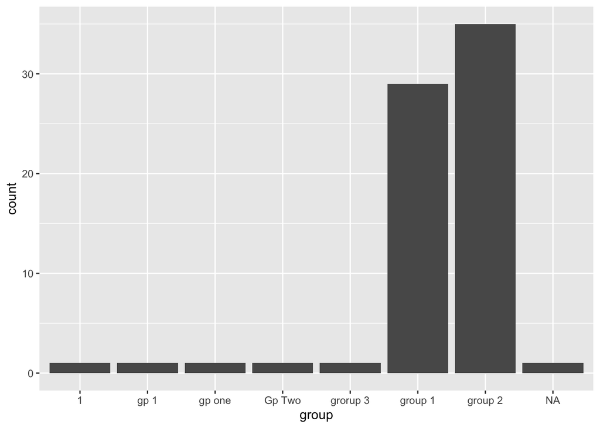

```r
# categorical - group
# bar graph
ggplot(data = testing, mapping = aes(x = group)) +
  geom_bar()
```

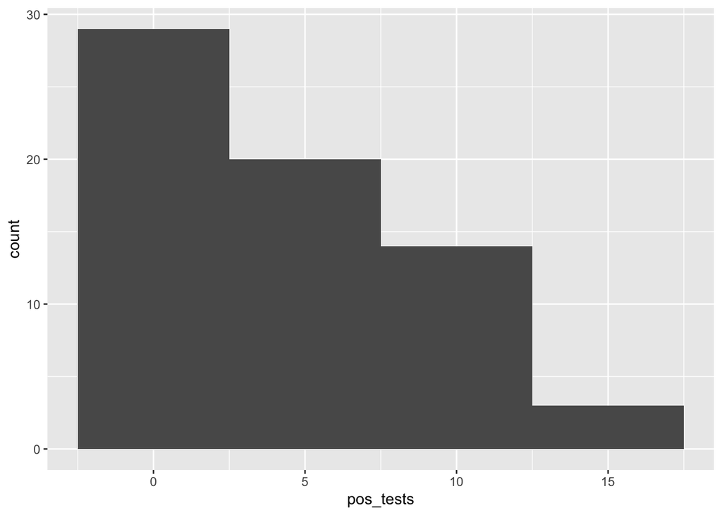

```r
# continuous - positive tests
# histogram
ggplot(data = testing, mapping = aes(x = pos_tests)) +
  geom_histogram(binwidth = 5)
```

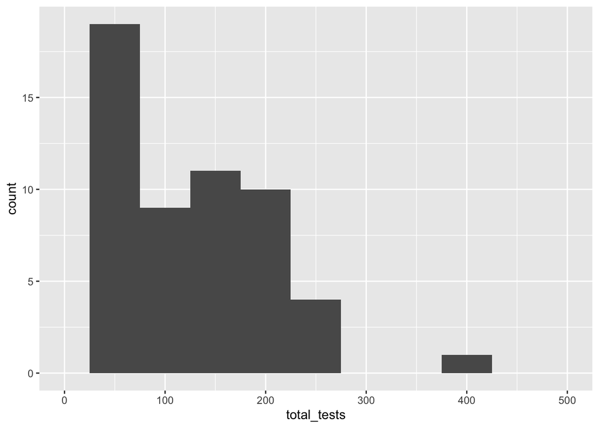

```r
# continuous - total tests
# histogram
ggplot(data = testing, mapping = aes(x = total_tests)) +
  geom_histogram(binwidth = 50) +
  xlim(0, 500)
```

#### Two variables

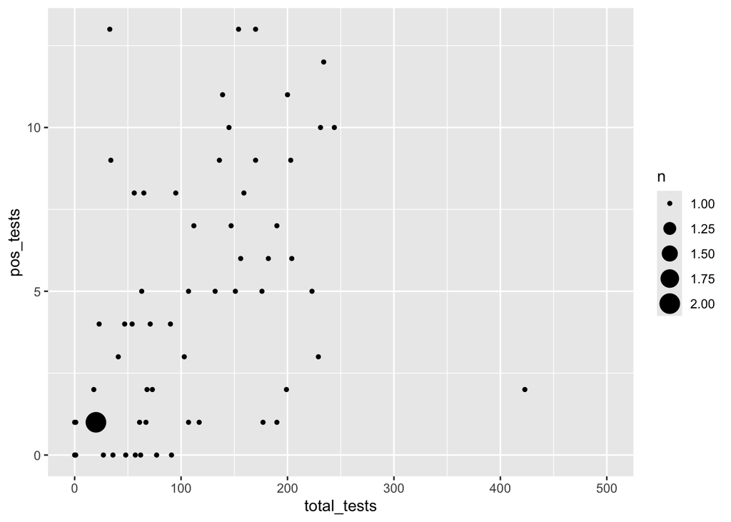

```r
# two continuous
# scatterplot
ggplot(data = testing, mapping = aes(x = total_tests, y = pos_tests)) +
  geom_count() +
  xlim(0, 500)
```

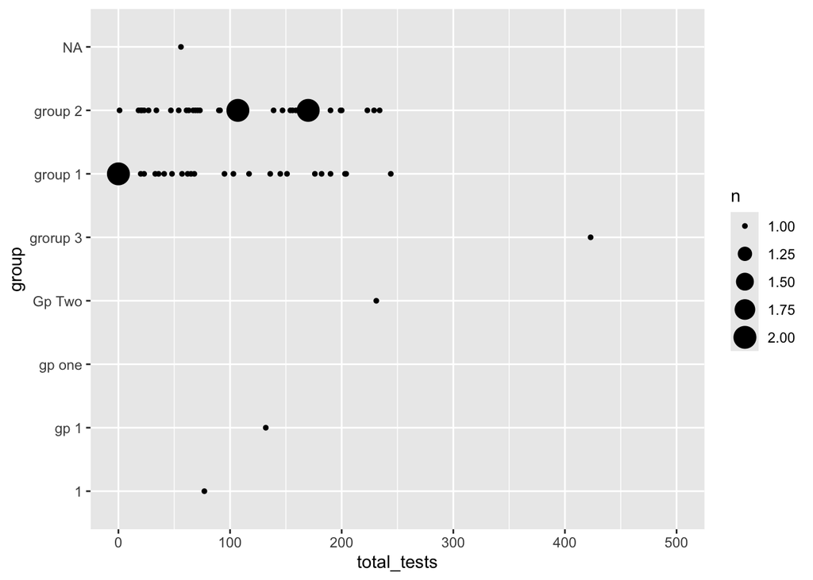

```r
# one continuous, one categorical
# scatterplot
ggplot(data = testing, mapping = aes(x = total_tests, y = group)) +
  geom_count() +
  xlim(0, 500)
```

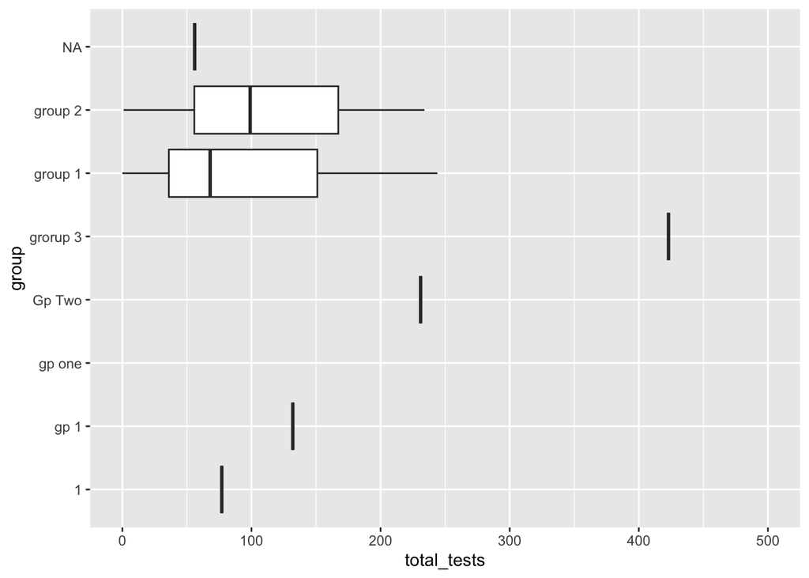

```r
# one categorical, one continuous
# boxplot
ggplot(data = testing, mapping = aes(x = total_tests, y = group)) +
  geom_boxplot() +
  xlim(0, 500)
```

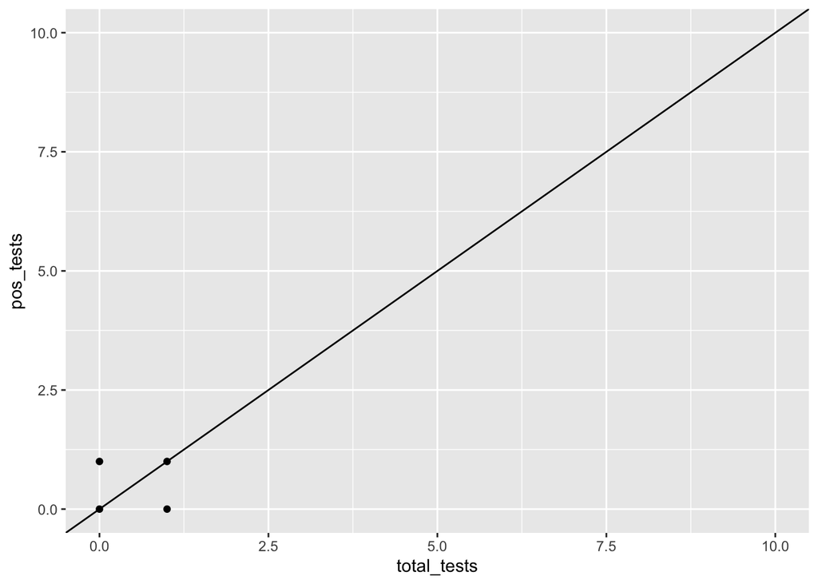

```r
# two continuous
# scatterplot + trend line
ggplot(data = testing, mapping = aes(x = total_tests, y = pos_tests)) +
  geom_point() +
  geom_abline(intercept = 0, slope = 1) +
  xlim(0,10) +
  ylim(0,10)
```

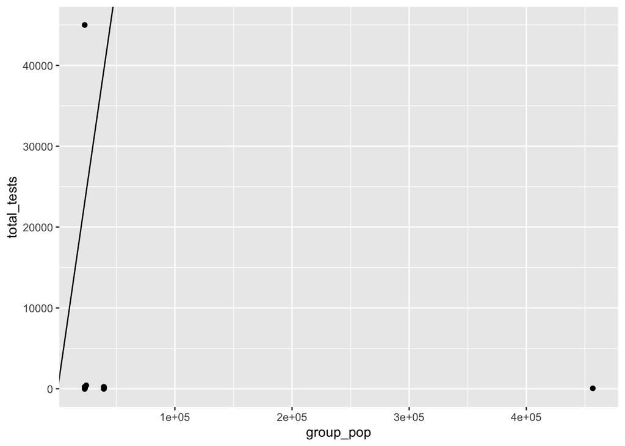

```r
# one continuous, one categorical
# scatterplot + trend line
ggplot(data = testing_temp, mapping = aes(x = group_pop, y = total_tests)) +
  geom_point()  +
  geom_abline(intercept = 0, slope = 1)
```

Field

Issue

Total tests

- “NA” vs NA; numeric
- Outlier
- Missing values

Positive tests

- Missing values
- Greater than total tests